# Homework 1

Sidharth, Kaiyi, Kai, Eric Song

九月 13, 2017

# 2.0 Introduction

[interactive chart not shown]

*“We uploaded a video wherein we intrudouce ourselves and then share our favorite quote, our hobbies and our class schedules. THen we followed the instructions in the homework to complete all the tasks.”*

## Group Members

### 2.1 Sidharth

**Picture:**

[figure not shown]

Indian Flag

**My Favorite Hobby & Interesting Fact:**

*“In my free time, I enjoy acrylic painting and pencil sketching. An interesting fact about me is that I have been to 2000 feet below the earch in a gold mine in India.”*

**Favorite Quote:**

> *“What barrier is there that love cannot break.”* Gandhi (1927)

**My Class Schedule:**

| Course | Time |
| --- | --- |
| Stat500 | 2:30pm MWF |
| Stat297 | 12:05am TR |
| Econ402 | 10:35am TR |
| EME 590 | 1:00pm F |

### 2.2 Kaiyi Wu

**Picture:**

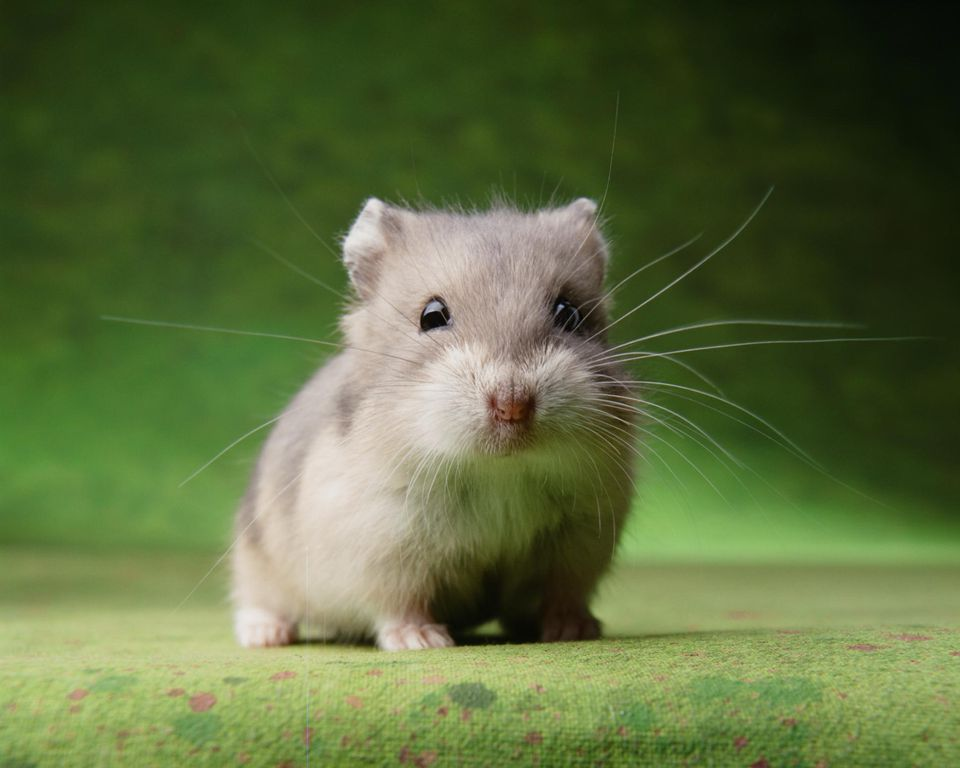

Cute Hamster

**My Class Schedule:**

| Course | Time |
| --- | --- |
| Stat513 | 09:05am MWF |
| Kines17 | 10:10am MWF |
| Stat466 | 11:15pm MWF |
| Kines77 | 09:05am TTr |
| Stat297 | 12:05pm TTr |

**My Favorite Hobby & Interesting Fact:** *“My hobby is baking. The interesting fact is that I have diffcuilty to read articles of capitcal letters. I didn’t start to learn English until junior high, and thus I learnt with very formal textbooks, which are all in lower cases!”*

**Favorite Quote:**

> *“The truth has never been of any real value to any human being; it is a symbol for mathematicians and philosophers to pursue. In human relations kindness and lies are worth a thousand truths.”* Greene (1948)

### 2.3 Kai

**Picture:**

[figure not shown]

Microsoft Logo

| Course | Time |
| --- | --- |
| Stat461 | 3:35pm MWF |
| Stat297 | 12:05am TH |
| Stat414 | 1:25Pm MWF |
| Math230 | 4:40pm MWF |
| Astro | Online |

**My Favorite Hobby & Interesting Fact:** Eat and travel. I have been to 40 different countries.

**Favorite Quote:** What doesn’t kill you makes you stronger.

### 2.4 Eric Song

**Picture:**

[figure not shown]

Science Department Banner

**Favorite Quote:**

> *“When Alexander saw the breadth of his domain, he wept for there were no more worlds to conquer.”* Plutarch (46AD–120AD)

**My Class Schedule:**

| Course | Time |
| --- | --- |
| Stat461 | 8:00am MWF |
| Math141 | 9:00am MWF |
| Psych470 | 1:30pm MWF |
| Psych260 | 10:30am TTr |
| Stat297 | 12:00pm TTr |

## 4.0 R Markdown Syntax

### 4.1 Chunk

### 4.2

```r
x = rnorm(100)
(mean = mean (x))
```

```
## [1] 0.06011675
```

```r
(median = median(x))
```

```
## [1] 0.01533598
```

```r
(variance = var(x))
```

```
## [1] 1.054626
```

```r
if(mean == 0){
  print("The mean is equal to the theoretical value")
} else{
  print("The mean is not equal to the theoretical value")
}
```

```
## [1] "The mean is not equal to the theoretical value"
```

```r
if(median == 0){
  print("The median is equal to the theoretical value")
} else{
  print("The median is not equal to the theoretical value")
}
```

```
## [1] "The median is not equal to the theoretical value"
```

```r
if(variance == 1){
  print("The variance is equal to the theoretical value")
} else{
  print("The variance is not equal to the theoretical value")
}
```

```
## [1] "The variance is not equal to the theoretical value"
```

### 4.3 hist graph

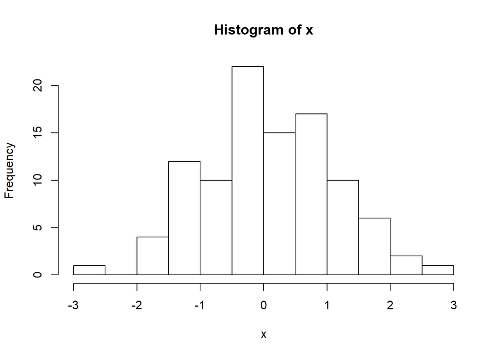

The histgram of x

```r
hist(x)
```

### 4.4 equation

$$\begin{aligned}
\mathbb{E} \left[ \text{var} \left\{
\boldsymbol{v}_1\left(
\hat{\boldsymbol{\theta}},n\right) \big|
\hat{\boldsymbol{\theta}} \right\} \right]
&=
\text{var} \left\{ \mathbf{v}_1\left(
\boldsymbol{\theta}_0,n\right) \right\} +
\mathbb{E} \left[\mathcal{O}_p\left\{
{\bf D}_1(\boldsymbol{\theta}^*,n)(\hat{\boldsymbol{\theta}} - \boldsymbol{\theta}_{0}),
\dots,
{\bf D}_p(\boldsymbol{\theta}^*,n)(\boldsymbol{\theta} - \boldsymbol{\theta}_{0})
\right\}\right]\\
&= \text{var} \left\{ \mathbf{v}_1\left( \boldsymbol{\theta}_0,n\right) \right\} + \mathcal{O}\left(n^{-2}\right).
\end{aligned}$$

In-line Equation:$\mathbf{A} \equiv \left[a_{i,j}\right]_{i,j = 1, \ldots, p}$

## References

Gandhi, Mahatma. 1927. “The Stories of My Experiment with the Truth.”

Greene, Graham. 1948. “The Heart of the Matter.”

Plutarch. 46AD–120AD. “Life of Alexander.”